# Tugas Individu TPM

Nazuwa Aulia (G1401211033)

2024-02-25

# Library

```r
library(keras)
library(caret)
library (dplyr)
library(tensorflow)
library(tidyverse)
library(knitr)
```

# Pendahuluan

Artificial Neural Network (ANN) adalah pendekatan komputasi yang bertujuan meniru proses transfer informasi otak manusia. Biasanya, ANN adalah teknik yang digunakan ketika hubungan antara input dan output sangat kompleks dan nonlinier (Garrett 1994). Secara umum, model Neural Network terdiri dari input layer, hidden layer, dan output layer dengan fungsi aktivasi di dalamnya. Metode ini menggunakan algoritma untuk membuat prediksi atau klasifikasi pada data input hingga mendapatkan output yang menggambarkan keadaan yang sebenarnya dengan akurat (Nielsen 2015).

# Data

```r
data.ann <- read.csv("C:/Users/Nazuwa Aulia/OneDrive/Documents/College/Semester 6/Teknik Pembelajaran Mesin/Pertemuan 5/data ann.csv")

head(data.ann)
```

```
##   besar.pinjaman lama.pembayaran bunga pembayaran.per.bulan banyak.cash.back
## 1             70               4     1                  130             10.0
## 2            120               3     5                   15              2.0
## 3             70               4     1                  260              9.0
## 4             50               4     0                  140             14.0
## 5            110               2     2                  180              1.5
## 6            110               2     0                  125              1.0
##     rating
## 1 68.40297
## 2 33.98368
## 3 59.42551
## 4 93.70491
## 5 29.50954
## 6 33.17409
```

## Eksplorasi Data

```r
str(data.ann)
```

```
## 'data.frame':    75 obs. of  6 variables:
##  $ besar.pinjaman      : int  70 120 70 50 110 110 130 90 90 120 ...
##  $ lama.pembayaran     : int  4 3 4 4 2 2 3 2 3 1 ...
##  $ bunga               : int  1 5 1 0 2 0 2 1 0 2 ...
##  $ pembayaran.per.bulan: int  130 15 260 140 180 125 210 200 210 220 ...
##  $ banyak.cash.back    : num  10 2 9 14 1.5 1 2 4 5 0 ...
##  $ rating              : num  68.4 34 59.4 93.7 29.5 ...
```

Data terdiri dari 75 amatan dengan semua peubah bersifat numerik. 6 peubah pada data terdiri dari 5 peubah penjelas dan 1 peubah respon. Peubah penjelas yang digunakan adalah sebagai berikut :

- Besar pinjaman (dalam juta rupiah)
- Lama pembayaran (dalam tahun)
- Tambahan bunga yang ditetapkan (dalam %)
- Pembayaran per bulan (dalam 10000)
- Banyak cash back yang diterapkan pada skema tersebut

```r
summary(data.ann)
```

```
##  besar.pinjaman  lama.pembayaran     bunga       pembayaran.per.bulan
##  Min.   : 50.0   Min.   :1.000   Min.   :0.000   Min.   :  0.0
##  1st Qu.:100.0   1st Qu.:2.000   1st Qu.:0.000   1st Qu.:132.5
##  Median :110.0   Median :3.000   Median :1.000   Median :180.0
##  Mean   :106.9   Mean   :2.547   Mean   :1.013   Mean   :160.2
##  3rd Qu.:110.0   3rd Qu.:3.000   3rd Qu.:1.500   3rd Qu.:215.0
##  Max.   :160.0   Max.   :6.000   Max.   :5.000   Max.   :320.0
##  banyak.cash.back     rating
##  Min.   : 0.000   Min.   :18.04
##  1st Qu.: 0.500   1st Qu.:32.69
##  Median : 2.000   Median :40.40
##  Mean   : 2.183   Mean   :42.48
##  3rd Qu.: 3.000   3rd Qu.:50.80
##  Max.   :14.000   Max.   :93.70
```

Dengan menggunakan fungsi summary dapat dilihat sebaran data secara umum.

## Pengecekan Missing Value

```r
colSums(is.na(data.ann))
```

```
##       besar.pinjaman      lama.pembayaran                bunga
##                    0                    0                    0
## pembayaran.per.bulan     banyak.cash.back               rating
##                    0                    0                    0
```

dengan menggunakan fungsi is.na dapat dilihat pada output diatas bahwa tidak terdapat missing value pada data.

## Sebaran Peubah

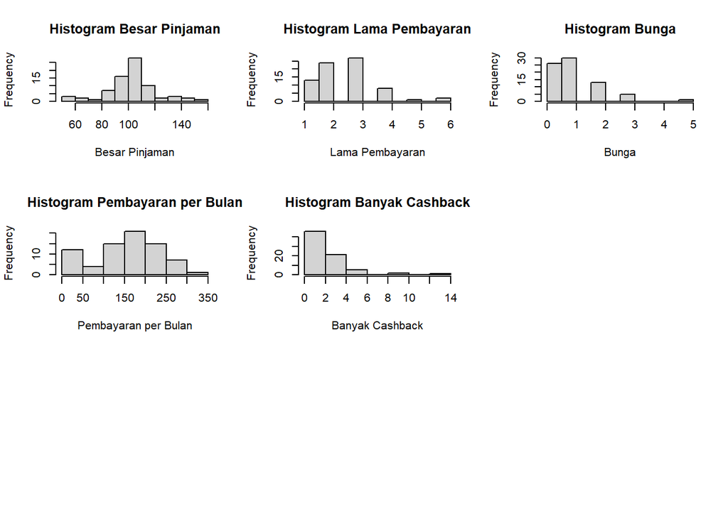

```r
par(mfrow=c(3, 3))

hist(data.ann$besar.pinjaman, main="Histogram Besar Pinjaman", xlab="Besar Pinjaman")
hist(data.ann$lama.pembayaran, main="Histogram Lama Pembayaran", xlab="Lama Pembayaran")
hist(data.ann$bunga, main="Histogram Bunga", xlab="Bunga")
hist(data.ann$pembayaran.per.bulan, main="Histogram Pembayaran per Bulan", xlab="Pembayaran per Bulan")
hist(data.ann$banyak.cash.back, main="Histogram Banyak Cashback", xlab="Banyak Cashback")
```

# Pra-Processing Data

## Normalisasi Data

Proses normalisasi data dilakukan dengan menggunakan fungsi (scale). Normalisasi peubah dilakukan pada seluruh peubah kecuali peubah respon yaitu rating.

```r
data.ann.normal <- as.data.frame(scale(data.ann[,-6]))
data.ann.normal$rating <- data.ann$rating
head(data.ann.normal)
```

```
##   besar.pinjaman lama.pembayaran       bunga pembayaran.per.bulan
## 1     -1.8723125       1.3135571 -0.01324532           -0.3581621
## 2      0.6624066       0.4097334  3.96035175           -1.7220242
## 3     -1.8723125       1.3135571 -0.01324532            1.1835951
## 4     -2.8862001       1.3135571 -1.00664459           -0.2395653
## 5      0.1554628      -0.4940903  0.98015394            0.2348215
## 6      0.1554628      -0.4940903 -1.00664459           -0.4174604
##   banyak.cash.back   rating
## 1       3.24677497 68.40297
## 2      -0.07586699 33.98368
## 3       2.83144472 59.42551
## 4       4.90809594 93.70491
## 5      -0.28353211 29.50954
## 6      -0.49119724 33.17409
```

## Sebaran Peubah Setelah Normalisasi

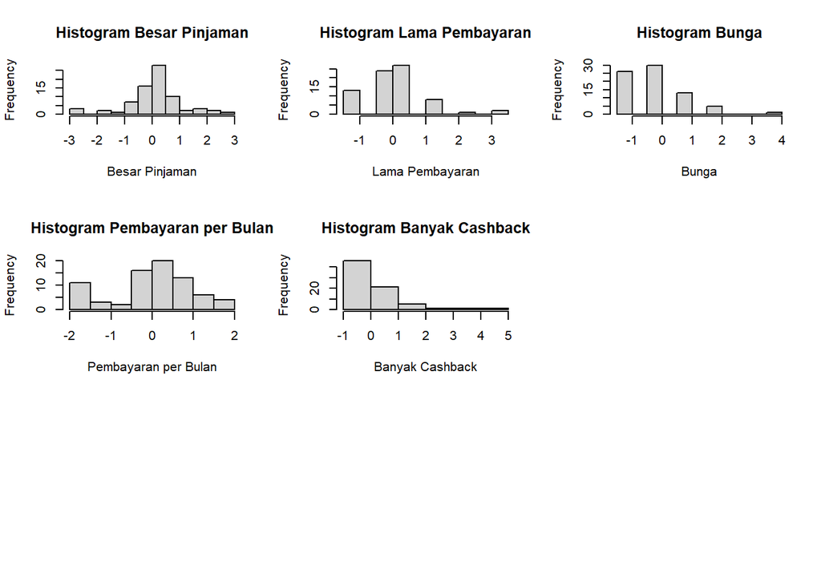

```r
par(mfrow=c(3, 3))

hist(data.ann.normal$besar.pinjaman, main="Histogram Besar Pinjaman", xlab="Besar Pinjaman")
hist(data.ann.normal$lama.pembayaran, main="Histogram Lama Pembayaran", xlab="Lama Pembayaran")
hist(data.ann.normal$bunga, main="Histogram Bunga", xlab="Bunga")
hist(data.ann.normal$pembayaran.per.bulan, main="Histogram Pembayaran per Bulan", xlab="Pembayaran per Bulan")
hist(data.ann.normal$banyak.cash.back, main="Histogram Banyak Cashback", xlab="Banyak Cashback")
```

# Analisis Neural Network

## Pembagian Data Uji dan Latih

```r
set.seed(033)

train.index <- createDataPartition(data.ann.normal$rating, p = 0.7, list = F)
train <- data.ann[train.index,]
test <- data.ann[-train.index,]
```

Setelah dilakukan pembagian data akan dilakukan proses scalling yang memiliki nilai diantara 0 hingga 1.

## Scalling Nilai Maksimum dan Minimum

Tahap analisis berikutnya adalah proses scalling data. Proses scalling data yang diterapkan adalah normalisasi data dari nilai minimum dan maksimum sehingga nilai data diperoleh dalam rentang 0 hingga 1. Proses penyetelan skala dilakukan melalui fungsi preProcess

```r
preprocessParams <- preProcess(train[,-6], method = c("range"))
train_X <- as.matrix(predict(preprocessParams, train[,-6]))
test_X <- as.matrix(predict(preprocessParams, test[,-6]))

train_y <- train[,6]
test_y <- test[,6]
```

## Model Neural Network dengan 2 Hidden Layer

Pengaturan model yang akan digunakan adalah menggunakan 2 hidden layer dimana masing-masing layer memiliki 256 neuron. Selain itu, untuk menghindari overfitting, ditambahkan dropout pada masing-masing layer dengan rate=0.3. Adapun untuk output layer menggunakan fungsi aktivasi linear dengan 1 neuron.Selain itu, ditentukan juga fungsi aktivasi yang terkandung dalam setiap layer berupa fungsi aktivasi linear atau relu. Pada analisis ini ditentukan nilai epoch sebesar 500, batch size sebesar 64, dan validation split sebesar 0.2.

Pengaturan lainnya untuk proses kompilasi model yaitu loss menggunakan nilai mean_squared_error, optimizer menggunakan adam serta untuk metrics menggunakan mean_squared_error dan mean_absolute_error.

```r
# Membuat model neural network dengan 2 hidden layer
model <- keras_model_sequential() %>%
  layer_dense(units = 256, activation = "relu", input_shape = ncol(train_X)) %>%
  layer_dropout(0.3) %>%
  layer_dense(units = 256, activation = "relu") %>%
  layer_dropout(0.3) %>%
  layer_dense(units = 1, activation = "linear")

# Mengkompilasi model
model %>% compile(
  loss = "mean_squared_error",
  optimizer = "adam",
  metrics = list("mean_squared_error", "mean_absolute_error")
)

# Melakukan tahapan pelatihan model
history <- model %>% fit(
  train_X, train_y,
  shuffle = T,
  epochs = 500,
  batch_size = 64,
  validation_split = 0.2
)
```

```r
print(model)
```

```
## Model: "sequential"
## ________________________________________________________________________________
##  Layer (type)                       Output Shape                    Param #
## ================================================================================
##  dense_2 (Dense)                    (None, 256)                     1536
##  dropout_1 (Dropout)                (None, 256)                     0
##  dense_1 (Dense)                    (None, 256)                     65792
##  dropout (Dropout)                  (None, 256)                     0
##  dense (Dense)                      (None, 1)                       257
## ================================================================================
## Total params: 67585 (264.00 KB)
## Trainable params: 67585 (264.00 KB)
## Non-trainable params: 0 (0.00 Byte)
## ________________________________________________________________________________
```

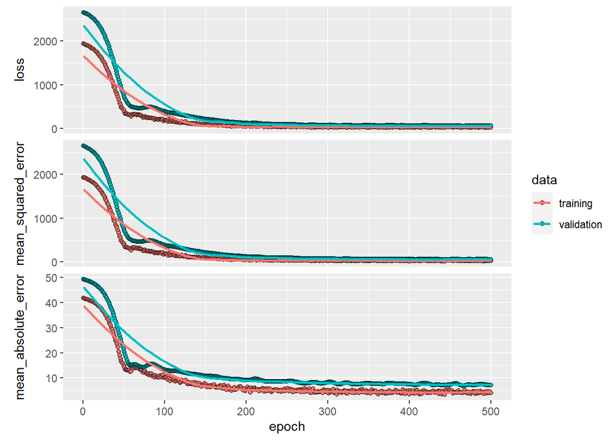

```r
# Menampilkan plot pembelajaran model pada setiap epoch
plot(history)
```

## Prediksi Model

Selanjutnya dilakukan prediksi nilai respon berdasarkan nilai-nilai peubah penjelas dengan menggunakan fungsi predict pada data uji

```r
prediksi <- predict(model, test_X)
```

```
## 1/1 - 0s - 130ms/epoch - 130ms/step
```

```r
head(prediksi)
```

```
##          [,1]
## [1,] 67.59605
## [2,] 30.75294
## [3,] 20.67591
## [4,] 27.43130
## [5,] 41.53913
## [6,] 39.52592
```

## Evaluasi Model

Evaluasi model dilakukan pada data uji berdasarkan model Neural Network yang didapatkan pada data latih. Proses evaluasi model dilakukan dengan memanfaatkan fungsi evaluate dengan parameter loss, MSE, dan MAE.

```r
# Mengevaluasi model menggunakan data uji
scores <- model %>% evaluate(test_X, test_y)
```

```
## 1/1 - 0s - loss: 29.2380 - mean_squared_error: 29.2380 - mean_absolute_error: 4.3175 - 37ms/epoch - 37ms/step
```

```r
print(scores)
```

```
##                loss  mean_squared_error mean_absolute_error
##           29.238028           29.238028            4.317512
```

```r
keras_train <- model %>% predict(train_X)
```

```
## 2/2 - 0s - 29ms/epoch - 15ms/step
```

```r
keras_test <- model %>% predict(test_X)
```

```
## 1/1 - 0s - 33ms/epoch - 33ms/step
```

```r
postResample(keras_train[,1], train$rating) #data latih
```

```
##      RMSE  Rsquared       MAE
## 5.0357876 0.8891879 4.1358916
```

```r
postResample(keras_test[,1], test$rating) #data uji
```

```
##     RMSE Rsquared      MAE
## 5.407220 0.829821 4.317512
```

Berdasarkan output diatas dapat dilihat bahwa nilai RMSE yang dihasilkan memiliki nilai RMSE yang cukup kecil dengan R-Squared sekitar 82%.

# Kesimpulan

Berdasarkan hasil analisis yang dilakukan dapat disimpulkan bahwa model Neural Network yang terdiri dari dua hidden layer dan masing-masing terdiri atas 256 neuron dapat dikategorikan sebagai model yang cukup baik dalam memprediksi rating skema pinjaman berdasarkan peubah-peubah penjelas di perusahaan perbankan hal tersebut dapat dilihat dengan nilai RMSE yang cukup kecil dan R-squared yang diperoleh sekitar 82%